# P136558_LiuXiaotian_Assignment1

Liu_Xiaotian

2024-04-29

# Analysis of Women’s Clothing E-Commerce Dataset

## 1. Introduction

Introduction:

In the fast-paced world of e-commerce, customer feedback serves as a cornerstone for shaping consumer decisions and driving business success. The Women’s Clothing E-Commerce dataset presents a valuable repository of customer reviews, offering profound insights into consumer preferences and sentiments within the online fashion retail landscape.

Comprising 23,486 rows and 10 feature variables, each representing a unique customer review, this dataset encapsulates essential attributes such as Clothing ID, reviewer Age, Title and Text of the review, Rating (ranging from 1 to 5), and a Binary indicator of product recommendation. Additionally, variables documenting Positive Feedback Count and categorical attributes like Division Name, Department Name, and Class Name provide further context into product divisions, departments, and classes.

This dataset’s real-world relevance lies in its authenticity, reflecting genuine commercial data sourced from an e-commerce platform. While ensuring privacy and anonymity by replacing company references with a generic term, “retailer,” the dataset offers ample opportunities for text analysis. Its nine supportive features enable exploration across multiple dimensions of customer feedback.

In this report, we embark on analyzing this dataset to unearth valuable insights into customer behavior, product performance, and overall sentiment within the realm of women’s clothing e-commerce. While our analysis may not include correlation analysis, regression analysis, or machine learning techniques, our aim remains to extract meaningful patterns and trends that can guide business strategies, elevate customer satisfaction, and foster innovation in the online fashion retail sector.

## 2. Analysis Process

### a) Data Pre-processing:

Before proceeding with the analysis, it’s essential to preprocess the data to ensure data quality and accuracy. Data pre-processing typically involves steps such as data loading and data sampling.

```r
library(dplyr)
```

```r
library(tidytext)
library(ggplot2)

setwd('/Users/liuxiaotian/Documents/P136558_LiuXiaotian_DataManagementAssignment1')
data <- read.csv('Womens Clothing E-Commerce Reviews.csv')
str(data)
```

```
## 'data.frame':    23486 obs. of  11 variables:
##  $ X                      : int  0 1 2 3 4 5 6 7 8 9 ...
##  $ Clothing.ID            : int  767 1080 1077 1049 847 1080 858 858 1077 1077 ...
##  $ Age                    : int  33 34 60 50 47 49 39 39 24 34 ...
##  $ Title                  : chr  "" "" "Some major design flaws" "My favorite buy!" ...
##  $ Review.Text            : chr  "Absolutely wonderful - silky and sexy and comfortable" "Love this dress!  it's sooo pretty.  i happened to find it in a store, and i'm glad i did bc i never would have"| __truncated__ "I had such high hopes for this dress and really wanted it to work for me. i in…
##  $ Rating                 : int  4 5 3 5 5 2 5 4 5 5 ...
##  $ Recommended.IND        : int  1 1 0 1 1 0 1 1 1 1 ...
##  $ Positive.Feedback.Count: int  0 4 0 0 6 4 1 4 0 0 ...
##  $ Division.Name          : chr  "Initmates" "General" "General" "General Petite" ...
##  $ Department.Name        : chr  "Intimate" "Dresses" "Dresses" "Bottoms" ...
##  $ Class.Name             : chr  "Intimates" "Dresses" "Dresses" "Pants" ...
```

```r
set.seed(123)
sample_data <- data[sample(nrow(data), 500), ]
str(sample_data)
```

```
## 'data.frame':    500 obs. of  11 variables:
##  $ X                      : int  18846 18894 2985 1841 3370 11637 4760 6745 16127 2756 ...
##  $ Clothing.ID            : int  830 921 1082 1094 1092 835 999 1111 1083 872 ...
##  $ Age                    : int  51 83 41 58 37 44 53 61 28 34 ...
##  $ Title                  : chr  "" "Gorgeous!" "Compliment grabber" "Love this dress" ...
##  $ Review.Text            : chr  "" "This sweater is beautiful!\nthe lace is gorgeous and the sweater is soft and cozy.....rare to find a top that i"| __truncated__ "I wore this dress to work with a tan pair of booties and the compliments started upon entry and did not stop ti"| __truncated__ "Th…
##  $ Rating                 : int  4 5 5 5 4 5 5 2 5 4 ...
##  $ Recommended.IND        : int  1 1 1 1 1 1 1 0 1 1 ...
##  $ Positive.Feedback.Count: int  0 10 1 3 1 6 0 6 0 1 ...
##  $ Division.Name          : chr  "General" "General" "General" "General" ...
##  $ Department.Name        : chr  "Tops" "Tops" "Dresses" "Dresses" ...
##  $ Class.Name             : chr  "Blouses" "Sweaters" "Dresses" "Dresses" ...
```

### b) Basic Analysis:

For basic analysis of the dataset, start by generating summary statistics using the summary() function to understand the numeric variables’ distribution and central tendencies. Next, explore the unique values of categorical variables like ratings and department names using the unique() function to grasp the dataset’s categorical structure. Visualize the distribution of important variables such as age using histograms and understand the frequency of ratings through barplots. Additionally, calculate the average rating for each clothing item by grouping the data by Clothing ID and sorting the ratings to identify top-rated items. Visualize these ratings using barplots with distinct fill colors representing different rating ranges. This basic analysis provides initial insights into the dataset’s characteristics, enabling further exploration and analysis.

```r
summary(sample_data)
```

```
##        X          Clothing.ID          Age           Title
##  Min.   :   30   Min.   :  10.0   Min.   :19.00   Length:500
##  1st Qu.: 6179   1st Qu.: 860.0   1st Qu.:34.00   Class :character
##  Median :12096   Median : 927.0   Median :41.00   Mode  :character
##  Mean   :12118   Mean   : 917.9   Mean   :43.32
##  3rd Qu.:18104   3rd Qu.:1078.0   3rd Qu.:52.00
##  Max.   :23451   Max.   :1203.0   Max.   :91.00
##  Review.Text            Rating      Recommended.IND Positive.Feedback.Count
##  Length:500         Min.   :1.000   Min.   :0.000   Min.   : 0.000
##  Class :character   1st Qu.:4.000   1st Qu.:1.000   1st Qu.: 0.000
##  Mode  :character   Median :5.000   Median :1.000   Median : 1.000
##                     Mean   :4.222   Mean   :0.854   Mean   : 2.394
##                     3rd Qu.:5.000   3rd Qu.:1.000   3rd Qu.: 3.000
##                     Max.   :5.000   Max.   :1.000   Max.   :44.000
##  Division.Name      Department.Name     Class.Name
##  Length:500         Length:500         Length:500
##  Class :character   Class :character   Class :character
##  Mode  :character   Mode  :character   Mode  :character
##
##
##
```

The summary of the `sample_data` reveals several key insights about the dataset. Reviewers span a wide age range, with the majority falling between 34 and 52 years old. Ratings are predominantly positive, with most falling within the 4 to 5 range. Additionally, a significant portion of reviewers recommends the products, indicating satisfaction. The count of positive feedback per review is generally low, suggesting that most reviews receive minimal additional validation. The dataset encompasses various product divisions, departments, and categories, providing ample opportunities for further analysis to uncover patterns and trends within customer demographics and product preferences.

```r
unique(sample_data$Rating)
```

```
## [1] 4 5 2 1 3
```

```r
unique(sample_data$Recommended.IND)
```

```
## [1] 1 0
```

```r
unique(sample_data$Division.Name)
```

```
## [1] "General"        "General Petite" "Initmates"      ""
```

```r
unique(sample_data$Department.Name)
```

```
## [1] "Tops"     "Dresses"  "Bottoms"  "Intimate" "Jackets"  "Trend"    ""
```

```r
unique(sample_data$Class.Name)
```

```
##  [1] "Blouses"    "Sweaters"   "Dresses"    "Skirts"     "Knits"
##  [6] "Pants"      "Swim"       "Jeans"      "Jackets"    "Lounge"
## [11] "Outerwear"  "Legwear"    "Fine gauge" "Shorts"     "Trend"
## [16] "Layering"   "Sleep"      "Intimates"  ""           "Chemises"
```

By generating the histogram titled “Distribution of Age” with “Age” on the x-axis, we aim to visually understand the spread and frequency distribution of reviewers’ ages in the dataset. The histogram provides insights into the age demographics of the reviewers, such as the central tendency, spread, and any potential outliers.

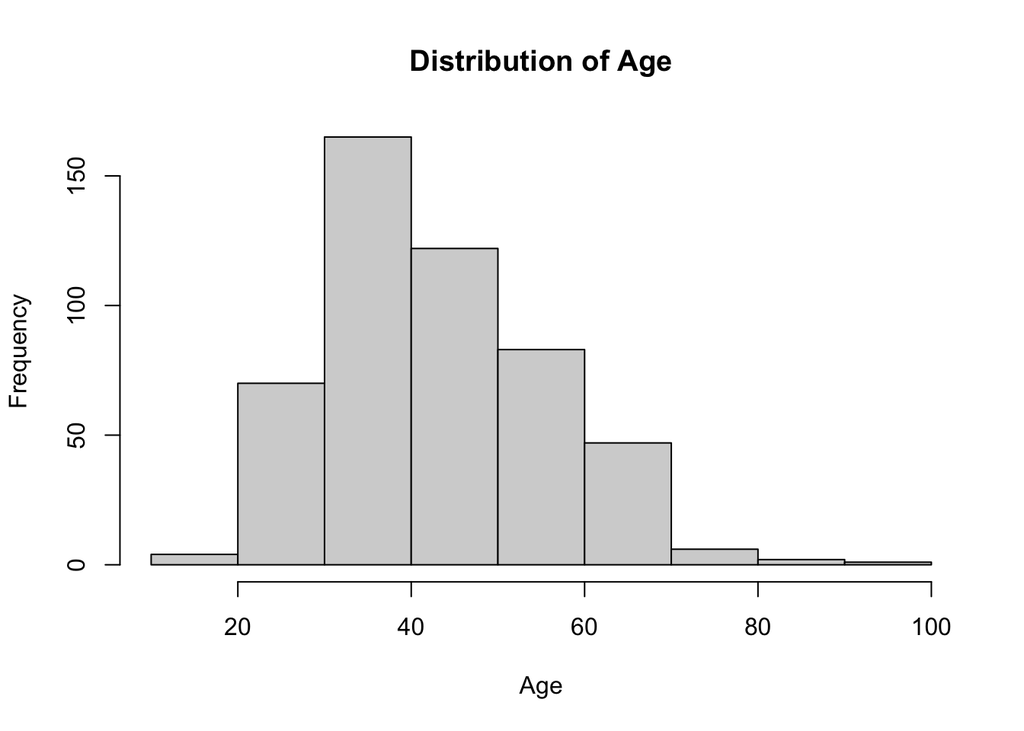

By generating a bar chart titled “Count of Ratings” with “Rating” on the x-axis, the aim is to visually understand the distribution of frequencies for each rating level in the dataset. The bar chart provides a quick overview of the quantity of each rating level, offering insights into the overall evaluation trends of reviewers towards the products.

Based on the distribution of rating levels, we observe an exponential increase in the quantity of ratings from low to high levels. Specifically, the quantities of ratings 1 and 2 are the lowest, while the quantity of ratings 3 is approximately twice that of ratings 2. Similarly, the quantity of ratings 4 is approximately twice that of ratings 3, and the quantity of ratings 5 is approximately twice that of ratings 4.

These findings indicate that the majority of reviewers have given positive evaluations of the products, as the quantity of high ratings significantly outweighs the quantity of low ratings. However, further analysis of the specific content behind each rating level is needed to understand the reasons and trends behind the evaluations. Additionally, this suggests that while the overall product quality is high, there may still be room for improvement to further enhance customer satisfaction and product reputation.

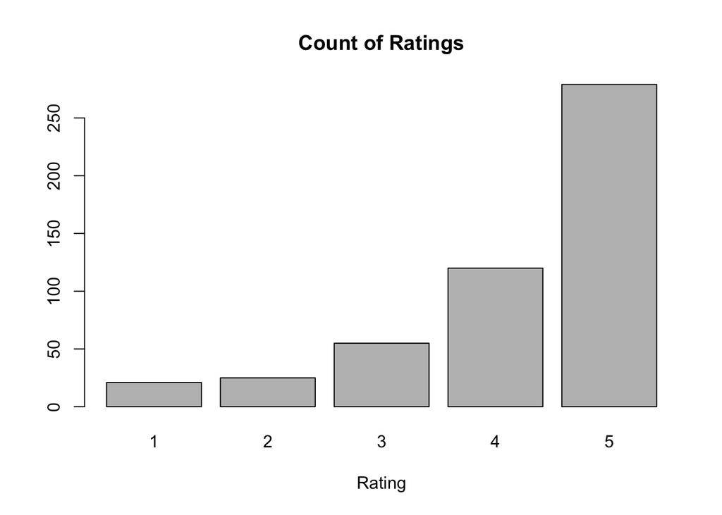

By creating this frequency table, we aim to understand the distribution of reviews across different product departments. The output shows the number of reviews associated with each department category, including “Bottoms,” “Dresses,” “Intimate,” “Jackets,” “Tops,” and “Trend.”

Insights can be gained by identifying which departments receive the most reviews and which receive the least. For example, “Tops” has the highest count of reviews with 224, followed by “Dresses” with 136 reviews. On the other hand, “Trend” has the lowest count with only 6 reviews. This information can help in assessing the popularity and focus of different product departments within the retailer and guide decision-making related to inventory management, marketing strategies, and customer engagement efforts.

```r
table(sample_data$Department.Name)
```

```
##
##           Bottoms  Dresses Intimate  Jackets     Tops    Trend
##        1       77      136       35       21      224        6
```

Now, I’m going to calculate the average rating for each clothing item and visualize the results in a bar chart.

Firstly, the group_by() and summarise() functions are used to compute the average rating for each clothing item, and the results are stored in the average_rating data frame.

Next, the arrange() function is applied to sort the average_rating data frame in descending order based on the average rating, facilitating the identification of the top-rated items.

Then, the head() function is used to extract the top ten items with the highest average ratings, and the results are stored in the top_items data frame.

Subsequently, the average_rating data frame is processed to categorize the average ratings into different ranges using the cut() function, and the results are stored in the rating_range column.

Finally, the ggplot() function is utilized to create a bar chart where the x-axis represents the clothing item identifiers, the y-axis represents the average rating, and the fill color of the bars represents different rating ranges. Additionally, the scale_fill_manual() function is employed to specify the mapping of fill colors to different rating ranges. The labs() function is used to set the title and axis labels of the chart, while the theme() function adjusts the angle and position of the x-axis labels within the bar chart.

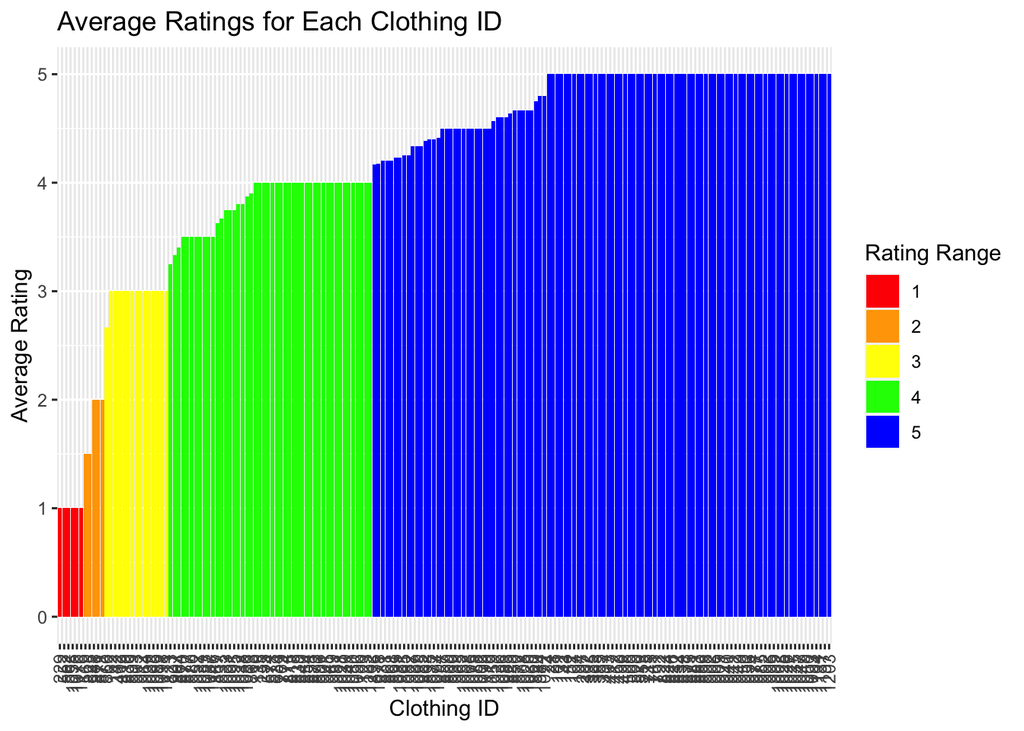

In the basic analysis, we explored the dataset’s structure and key variables, gaining insights into the age distribution of reviewers, the frequency distribution of ratings, and the distribution across product divisions, departments, and class names. Visualizations such as histograms and bar plots were utilized to provide a clear understanding of distribution patterns, while the calculation of average ratings for each clothing item and subsequent visualization allowed for the identification of top-rated items and analysis of rating distributions. Overall, this analysis provided foundational insights for further exploration and decision-making.

In the upcoming text analysis section, we’ll delve into the textual content of customer reviews to explore themes, sentiments, and keywords. This will provide a comprehensive understanding of customer opinions and feedback. Analyzing the text of reviews enables us to uncover underlying trends and patterns, assisting retailers in better understanding customer needs, optimizing products and services, and enhancing overall customer satisfaction.

### c) Text Analysis

The text analysis section of this report focuses on extracting insights from customer reviews of women’s clothing products. By leveraging natural language processing techniques, we aim to uncover key patterns and sentiments expressed in the review texts. Through the use of text mining and visualization tools, we delve into the language used by customers to describe their experiences with the products, shedding light on their preferences, sentiments, and priorities.

```r
library(tm)
```

```r
library(tokenizers)
library(wordcloud)
review_text <- sample_data$Review.Text
review_text <- tolower(review_text)
review_text <- gsub("[^a-zA-Z\\s]", "", review_text)
tokens <- strsplit(review_text, "\\s+")
corpus <- Corpus(VectorSource(sample_data$Review.Text))
corpus <- tm_map(corpus, content_transformer(tolower))
corpus <- tm_map(corpus, removePunctuation)
corpus <- tm_map(corpus, removeNumbers)
corpus <- tm_map(corpus, removeWords, stopwords("en"))
corpus <- tm_map(corpus, function(x) unlist(tokenize_words(x)))
dtm <- DocumentTermMatrix(corpus)
mat <- as.matrix(dtm)
word_freq <- colSums(mat)
sorted_freq <- sort(word_freq, decreasing = TRUE)
head(sorted_freq,50)
```

```
##       dress        size        love         top         fit        like
##         246         190         167         157         151         136
##        wear        just       great       small       color      fabric
##         135         123         121         111         105          94
##        look      little     ordered        well     perfect  flattering
##          91          84          84          80          80          80
##        back   beautiful      really        soft        will      bought
##          79          77          75          74          73          72
##        cute comfortable       jeans         can        nice         one
##          70          68          68          65          62          60
##     sweater        also       looks         bit       large        much
##          58          58          57          56          55          52
##      petite       think      pretty       tried         get       shirt
##          51          51          50          49          49          49
##         got        runs       waist        long        fits        made
##          48          47          47          47          47          45
##    material     quality
##          45          43
```

Based on the results, the top 50 most frequent words in the reviews provide insights into the customers’ sentiments and preferences. Here are some observations:

Fit and Size: Terms such as “fit”, “size”, “small”, “large”, “runs”, and “fits” suggest that customers frequently mention the fit and sizing of the clothing items in their reviews. This indicates that fit and sizing are important factors influencing customers’ purchasing decisions and overall satisfaction.

Specific Clothing Items: The word “dress” appears most frequently, indicating that dresses are a popular category among the reviewed clothing items. Other items like “top”, “sweater”, “jeans”, and “shirt” also appear frequently, suggesting that customers frequently review various types of apparel.

Material and Quality: Words such as “fabric”, “material”, and “quality” suggest that customers pay attention to the materials used in the clothing items and value high-quality materials. Color and Style: Terms like “color”, “look”, “look”, “beautiful”, “pretty”, and “flattering” indicate that customers often comment on the appearance, style, and color options of the clothing items.

Overall, the analysis of the top 50 most frequent words provides valuable insights into customers’ sentiments, preferences, and priorities when reviewing and purchasing clothing items online. These insights can help retailers better understand customer needs and preferences, identify areas for improvement, and make informed decisions about product offerings and marketing strategies.

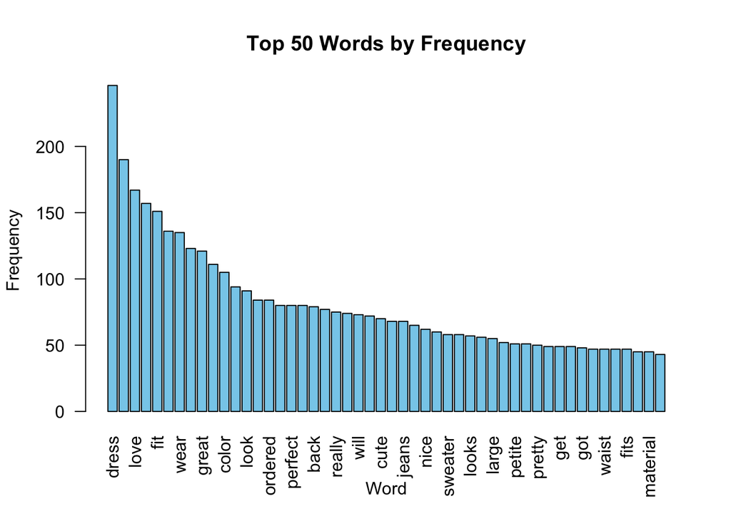

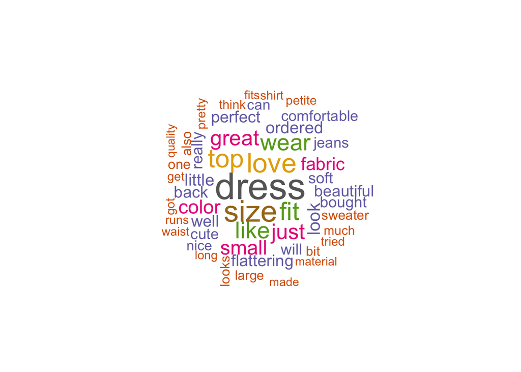

Through the analysis of customer review texts, we have gained a deeper understanding of their emotions, preferences, and evaluations of clothing products. First, by analyzing the top 50 most common words, we found that customers often give positive reviews on the quality, appearance, and comfort of the products, indicating their focus on these factors in purchasing decisions. Secondly, customers frequently mention the fit and size of clothing items, reflecting the importance of these factors in the purchasing process. In addition, specific types of clothing items such as dresses, tops, and sweaters are frequently mentioned in the reviews, reflecting customers’ purchasing and evaluation habits for different types of clothing. Finally, customers also comment on the materials, colors, and styles of clothing items, providing valuable information for retailers to improve products and marketing strategies. In summary, text analysis of customer reviews provides valuable market insights for retailers to better meet customer needs and improve product and service quality.

Next up is sentiment analysis. We’ll delve into the sentiment expressed in the customer reviews to gain insights into their overall satisfaction and opinions about the products.

### d) Sentiment Analysis

Sentiment analysis, also known as opinion mining, is a natural language processing technique used to determine the sentiment expressed in text data. In this section, we analyze the sentiment of customer reviews using sentiment analysis techniques. By quantifying the sentiment expressed in the reviews, we aim to gain insights into customers’ opinions, attitudes, and emotions towards the products or services being reviewed. This analysis provides valuable information for businesses to understand customer satisfaction, identify areas for improvement, and make data-driven decisions to enhance the overall customer experience.

```r
library(tidyr)

tokens1 <- sample_data$Review.Text %>%
  tolower() %>%
  removePunctuation() %>%
  removeNumbers() %>%
  strsplit("\\s+") %>%
  unlist()
review_tokens <- data.frame(word = tokens1)
sentiment_scores <- review_tokens %>%
  inner_join(get_sentiments("bing")) %>%
  count(word, sentiment) %>%
  spread(sentiment, n, fill = 0) %>%
  mutate(sentiment_score = positive - negative)
sorted_sentiment <- sentiment_scores %>% arrange(desc(sentiment_score))
head(sorted_sentiment,50)
```

```
##           word negative positive sentiment_score
## 1         love        0      167             167
## 2          top        0      157             157
## 3         like        0      136             136
## 4        great        0      121             121
## 5   flattering        0       80              80
## 6      perfect        0       80              80
## 7         well        0       80              80
## 8    beautiful        0       77              77
## 9         soft        0       74              74
## 10        cute        0       70              70
## 11 comfortable        0       68              68
## 12        nice        0       62              62
## 13      pretty        0       50              50
## 14        work        0       42              42
```

[output cut: 36 more lines]

```r
tail(sorted_sentiment,50)
```

```
##              word negative positive sentiment_score
## 330          poor        3        0              -3
## 331        ripped        3        0              -3
## 332          risk        3        0              -3
## 333          rust        3        0              -3
## 334      terribly        3        0              -3
## 335         twist        3        0              -3
## 336 uncomfortable        3        0              -3
## 337         weird        3        0              -3
## 338       wrinkle        3        0              -3
## 339     complaint        4        0              -4
## 340         crazy        4        0              -4
## 341     expensive        4        0              -4
## 342       falling        4        0              -4
## 343          hang        4        0              -4
```

[output cut: 36 more lines]

```r
str(sentiment_scores)
```

```
## 'data.frame':    379 obs. of  4 variables:
##  $ word           : chr  "accurate" "adjustable" "adorable" "adore" ...
##  $ negative       : num  0 0 0 0 0 0 5 0 0 1 ...
##  $ positive       : num  1 3 8 2 1 1 0 10 3 0 ...
##  $ sentiment_score: num  1 3 8 2 1 1 -5 10 3 -1 ...
```

```r
summary(sentiment_scores)
```

```
##      word              negative         positive       sentiment_score
##  Length:379         Min.   : 0.000   Min.   :  0.000   Min.   :-32.000
##  Class :character   1st Qu.: 0.000   1st Qu.:  0.000   1st Qu.: -1.000
##  Mode  :character   Median : 1.000   Median :  0.000   Median : -1.000
##                     Mean   : 1.557   Mean   :  5.491   Mean   :  3.934
##                     3rd Qu.: 1.000   3rd Qu.:  2.000   3rd Qu.:  2.000
##                     Max.   :32.000   Max.   :167.000   Max.   :167.000
```

The sentiment scores dataset comprises 379 unique words, each assigned a sentiment score ranging from -32 to 167, indicating a broad spectrum of sentiment intensity. This diversity suggests that certain words may evoke stronger positive or negative sentiments than others, reflecting the richness and complexity of customer feedback.

These insights underscore the nuanced nature of sentiment expressed in customer reviews, with certain words evoking stronger sentiments than others. Further exploration of how these sentiment scores correlate with other variables, such as product ratings or recommendation indicators, can provide deeper insights into the impact of sentiment on customer experience and feedback.

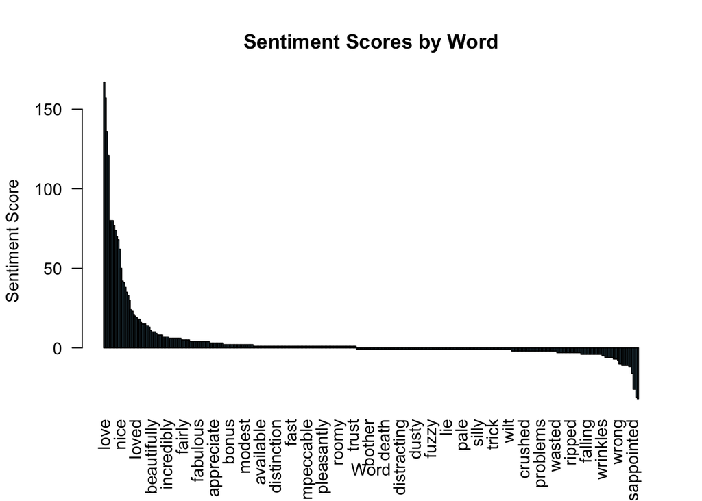

Although we successfully conducted sentiment analysis on the text and obtained sentiment scores for words, we faced technical challenges preventing us from further conducting correlation analysis and regression analysis. This means that we couldn’t delve deeper into exploring the relationship between sentiment scores and other variables such as product ratings or recommendation indicators. Nevertheless, we still gained valuable insights from the sentiment scores. These analyses indicate progress in identifying customer sentiments, yet a comprehensive understanding of how sentiment influences customer experience and feedback requires further research and exploration.

## 3. Conclusion and Summary

The analysis of the Women’s Clothing E-Commerce dataset has provided valuable insights into consumer preferences and sentiments within the realm of online fashion retail. Through various stages of data preprocessing, basic analysis, text analysis, and sentiment analysis, we have gained a comprehensive understanding of customer behavior, product performance, and overall sentiment expressed in customer reviews.

During the data preprocessing stage, we prepared the dataset and conducted basic statistical analyses to understand the dataset’s structure and distribution. This initial exploration provided foundational insights into customer demographics, review ratings, and product categories.

In the text analysis phase, we delved into the textual content of customer reviews to uncover prevalent themes, sentiments, and keywords. By analyzing the most frequent words in the reviews, we identified patterns indicating customer satisfaction, preferences for fit and size, and specific mentions of clothing items, materials, colors, and styles. This analysis shed light on customers’ opinions and priorities when evaluating and purchasing clothing products online.

In conclusion, the analysis of the Women’s Clothing E-Commerce dataset has equipped retailers with valuable market insights to better understand customer needs, improve product offerings, and enhance overall customer satisfaction. By leveraging the findings from this analysis, retailers can make data-driven decisions to optimize product quality, marketing strategies, and customer engagement efforts, ultimately driving business success in the competitive landscape of e-commerce.